# Biostat 212a Homework 2

Due Feb 6, 2024 @ 11:59PM

Author

Chengwu Duan (Jason) and UID: 606332825

Published

February 6, 2024

## 1 ISL Exercise 4.8.1 (10pts)

Using a little bit of algebra, prove that (4.2) is equivalent to (4.3). In other words, the logistic function representation and logit representation for the logistic regression model are equivalent.

$$\begin{align*}
p(X) &= \frac{e^{\beta_0 + \beta_1X}}{1 + e^{\beta_0 + \beta_1X}} && (4.2)\\
p(X) + p(X) \cdot e^{\beta_0 + \beta_1X} &= e^{\beta_0 + \beta_1X} \\
p(X) &= (1 - p(X)) \cdot e^{\beta_0 + \beta_1X} \\ \frac{p(X)}{1 - p(X)} &= e^{\beta_0 + \beta_1X} && (4.3)\\
\log_{e}(\frac{p(X)}{1 - p(X)}) &= \beta_0 + \beta_1X
\end{align*}$$
## ISL Exercise 4.8.6 (10pts)

Suppose we collect data for a group of students in a statistics class with variables X1 = hours studied, X2 = undergrad GPA, and Y = receive an A. We fit a logistic regression and produce estimated coefficient, $\hat{\beta}_0 = −6, \hat{\beta}_1 = 0.05, \hat{\beta}_2 = 1$.

(a) Estimate the probability that a student who studies for 40 h and has an undergrad GPA of 3.5 gets an A in the class.

**Answer:**
$$\begin{align*}
p(X) &= \frac{e^{\beta_0 + \beta_1X_1+\beta_2X_2}}
{1 + e^{\beta_0 + \beta_1X_1+\beta_2X_2}}\\
&= \frac{e^{-6 + 0.05 \cdot 40 + 1 \cdot 3.5}}{1 + e^{-6 + 0.05 \cdot 40 + 1 \cdot 3.5}}\\
&= \frac{e^{-0.5}}{1 + e^{-0.5}}\\
&= \frac{0.6065}{1 + 0.6065}\\
&= 0.3775\\
\end{align*}$$

(b) How many hours would the student in part (a) need to study to have a 50 % chance of getting an A in the class?

**Answer:**
$$\begin{align*}
p(X) &= \frac{e^{\beta_0 + \beta_1X + \beta_2X_2}}{1 + e^{\beta_0 + \beta_1X + \beta_2X_2}}\\
0.5 &= \frac{e^{-6 + 0.05 \cdot X + 1 \cdot 3.5}}{1 + e^{-6 + 0.05 \cdot X + 1 \cdot 3.5}}\\
0.5 + 0.5 \cdot e^{-6 + 0.05 \cdot X + 1 \cdot 3.5} &= e^{-6 + 0.05 \cdot X + 1 \cdot 3.5}\\
0.5 &= e^{-6 + 0.05 \cdot X + 1 \cdot 3.5} - 0.5 \cdot e^{-6 + 0.05 \cdot X + 1 \cdot 3.5}\\
0.5 &= 0.5 \cdot e^{-6 + 0.05 \cdot X + 1 \cdot 3.5}\\
1 &= e^{-6 + 0.05 \cdot X + 1 \cdot 3.5}\\
\ln(1) &= -6 + 0.05 \cdot X + 1 \cdot 3.5\\
6 - 3.5 &= 0.05 \cdot X\\
X &= \frac{6 - 3.5}{0.05}\\
X &= 50\\
\end{align*}$$

## 2 ISL Exercise 4.8.9 (10pts)

This problem has to do with odds.

(a) On average, what fraction of people with an odds of 0.37 of defaulting on their credit card payment will in fact default?

**Answer:**

$$\begin{align*}
odds &= \frac{p(X)}{1 - p(X)}\\
\frac{p(X)}{1 - p(X)} &= 0.37 \\
p(X) &= 0.37 - 0.37 \cdot p(X) \\
p(X) + 0.37 \cdot p(X)&= 0.37\\
p(X) &= \frac{0.37}{1.37}\\
&= 0.27\\
\end{align*}$$

(b) Suppose that an individual has a 16 % chance of defaulting on her credit card payment. What are the odds that she will default?

**Answer:**
$$\begin{align*}
odds &= \frac{p(X)}{1 - p(X)}\\
&= \frac{0.16}{1 - 0.16}\\
&= 0.19\\
\end{align*}$$

## 3 ISL Exercise 4.8.13 (a)-(i) (50pts)

This question should be answered using the Weekly data set, which is part of the ISLR2 package. This data is similar in nature to the Smarket data from this chapter’s lab, except that it contains 1, 089 weekly returns for 21 years, from the beginning of 1990 to the end of 2010.

```r
library(ISLR2)
data(Weekly)

head(Weekly)
```

```
  Year   Lag1   Lag2   Lag3   Lag4   Lag5    Volume  Today Direction
1 1990  0.816  1.572 -3.936 -0.229 -3.484 0.1549760 -0.270      Down
2 1990 -0.270  0.816  1.572 -3.936 -0.229 0.1485740 -2.576      Down
3 1990 -2.576 -0.270  0.816  1.572 -3.936 0.1598375  3.514        Up
4 1990  3.514 -2.576 -0.270  0.816  1.572 0.1616300  0.712        Up
5 1990  0.712  3.514 -2.576 -0.270  0.816 0.1537280  1.178        Up
6 1990  1.178  0.712  3.514 -2.576 -0.270 0.1544440 -1.372      Down
```

The variables are:

- Year: The recorded year of observations
- Lag1: % return for previous week
- Lag2: % return for 2 weeks previous
- Lag3: % return for 3 weeks previous
- Lag4: % return for 4 weeks previous
- Lag5: % return for 5 weeks previous
- Volume: average number of daily shares traded in billions
- Today: % return for current week
- Direction: A factor with levels Down and Up indicating whether the market had a negative or positive return on a given week
1. Produce some numerical and graphical summaries of the Weekly data. Do there appear to be any patterns?

**Answer:**

```r
summary(Weekly)
```

```
      Year           Lag1               Lag2               Lag3
 Min.   :1990   Min.   :-18.1950   Min.   :-18.1950   Min.   :-18.1950
 1st Qu.:1995   1st Qu.: -1.1540   1st Qu.: -1.1540   1st Qu.: -1.1580
 Median :2000   Median :  0.2410   Median :  0.2410   Median :  0.2410
 Mean   :2000   Mean   :  0.1506   Mean   :  0.1511   Mean   :  0.1472
 3rd Qu.:2005   3rd Qu.:  1.4050   3rd Qu.:  1.4090   3rd Qu.:  1.4090
 Max.   :2010   Max.   : 12.0260   Max.   : 12.0260   Max.   : 12.0260
      Lag4               Lag5              Volume            Today
 Min.   :-18.1950   Min.   :-18.1950   Min.   :0.08747   Min.   :-18.1950
 1st Qu.: -1.1580   1st Qu.: -1.1660   1st Qu.:0.33202   1st Qu.: -1.1540
 Median :  0.2380   Median :  0.2340   Median :1.00268   Median :  0.2410
 Mean   :  0.1458   Mean   :  0.1399   Mean   :1.57462   Mean   :  0.1499
 3rd Qu.:  1.4090   3rd Qu.:  1.4050   3rd Qu.:2.05373   3rd Qu.:  1.4050
 Max.   : 12.0260   Max.   : 12.0260   Max.   :9.32821   Max.   : 12.0260
 Direction
 Down:484
 Up  :605
```

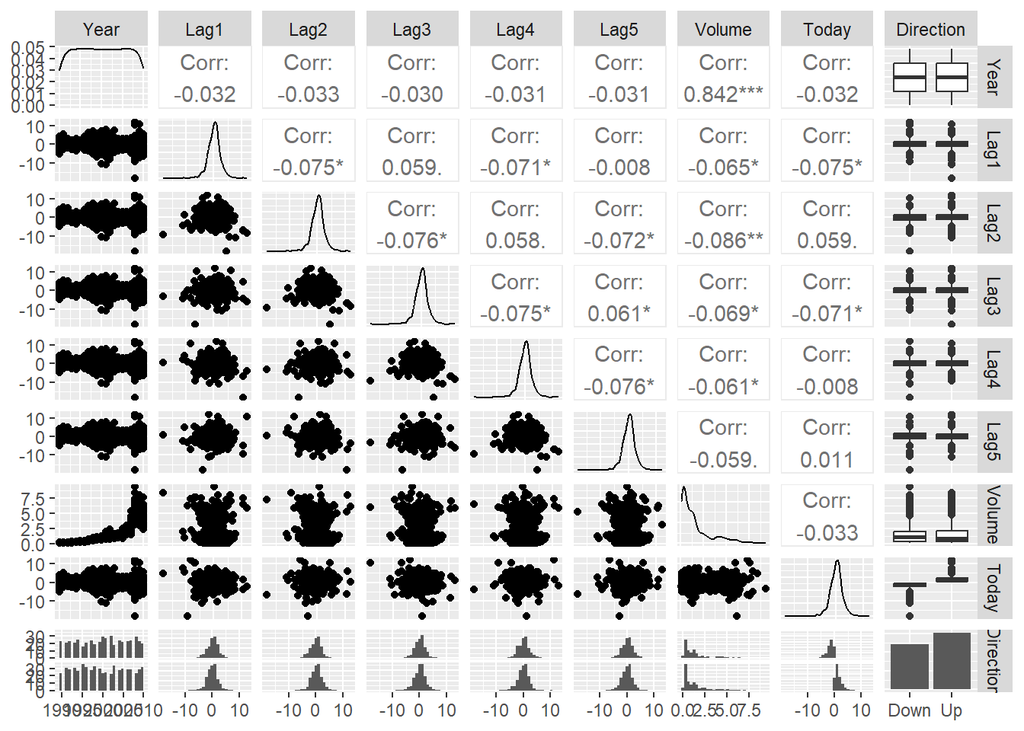

```r
library(ggplot2)
library(GGally)
ggpairs(Weekly)
```

```r
# excludes the Direction column since it is a response variable
cor(Weekly[ ,-9])
```

```
              Year         Lag1        Lag2        Lag3         Lag4
Year    1.00000000 -0.032289274 -0.03339001 -0.03000649 -0.031127923
Lag1   -0.03228927  1.000000000 -0.07485305  0.05863568 -0.071273876
Lag2   -0.03339001 -0.074853051  1.00000000 -0.07572091  0.058381535
Lag3   -0.03000649  0.058635682 -0.07572091  1.00000000 -0.075395865
Lag4   -0.03112792 -0.071273876  0.05838153 -0.07539587  1.000000000
Lag5   -0.03051910 -0.008183096 -0.07249948  0.06065717 -0.075675027
Volume  0.84194162 -0.064951313 -0.08551314 -0.06928771 -0.061074617
Today  -0.03245989 -0.075031842  0.05916672 -0.07124364 -0.007825873
               Lag5      Volume        Today
Year   -0.030519101  0.84194162 -0.032459894
Lag1   -0.008183096 -0.06495131 -0.075031842
Lag2   -0.072499482 -0.08551314  0.059166717
Lag3    0.060657175 -0.06928771 -0.071243639
Lag4   -0.075675027 -0.06107462 -0.007825873
Lag5    1.000000000 -0.05851741  0.011012698
Volume -0.058517414  1.00000000 -0.033077783
Today   0.011012698 -0.03307778  1.000000000
```

Based on the corvariates statistics, there are no apparent strong relationships between the `lag` variables. This means that the lag variables are not correlated with each other. And the only strong correlation is between `Year` and `Volume` which is 0.84. This means that the volume of trades has increased over the year, which we can see clearer in a plot of volume over year.

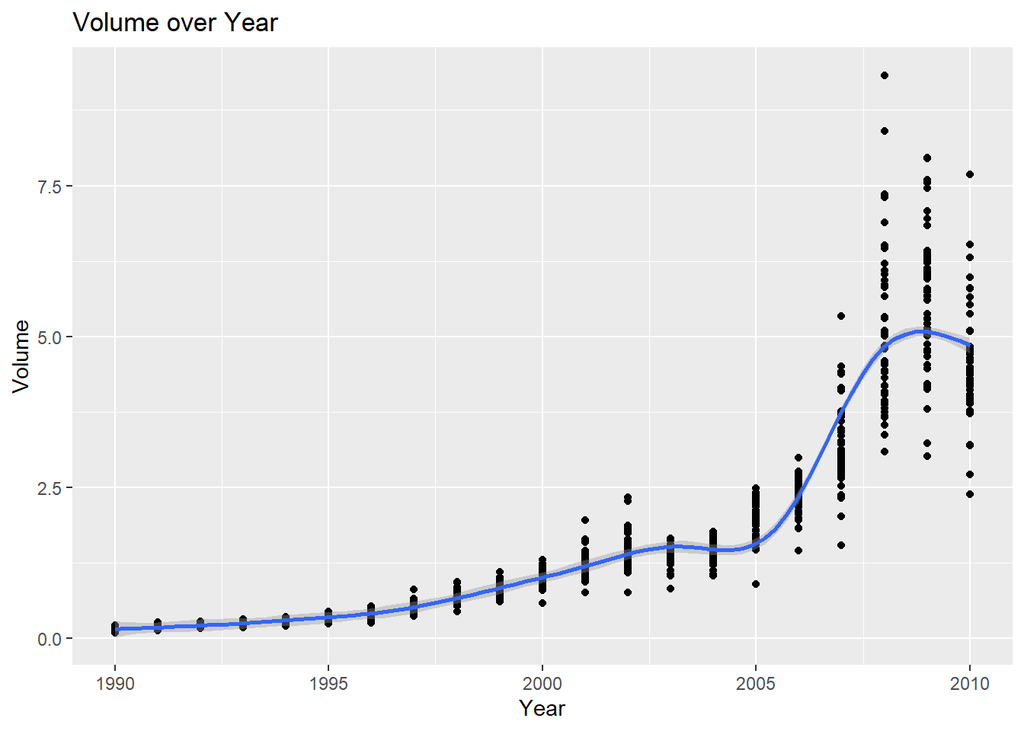

```r
library(ggplot2)
ggplot(Weekly, aes(x = Year, y = Volume)) + geom_point() + geom_smooth()+
  labs(title="Volume over Year")
```

Based on the volume over year, there is a significant increase in volume over the years. The volume trend peeked during 2009 and decreased in 2010. This could be due to the financial crisis that happened in 2008.

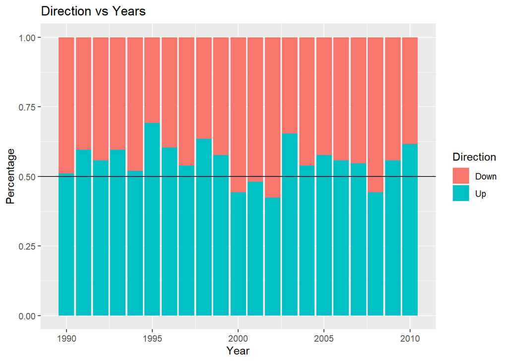

```r
ggplot(Weekly, aes(x = Year, fill = Direction)) +
  geom_bar(position = "fill") +
  geom_hline(yintercept = 0.5) +
  labs(y="Percentage", title="Direction vs Years")
```

Based on the Direction vs Time plot, majority of the years have higher than 50% of the weeks with positive returns. While there are some years that have more weeks with negative returns than positive returns, particularly in year 2000, 2001, 2002, and 2008.

2. Use the full data set to perform a logistic regression with Direction as the response and the five lag variables plus Volume as predictors. Use the summary function to print the results. Do any of the predictors appear to be statistically significant? If so, which ones?

**Answer:**

```r
lm.fit = glm(Direction ~ Lag1 + Lag2 + Lag3 + Lag4 + Lag5 + Volume, data = Weekly, family = binomial)

summary(lm.fit)
```

```
Call:
glm(formula = Direction ~ Lag1 + Lag2 + Lag3 + Lag4 + Lag5 +
    Volume, family = binomial, data = Weekly)

Coefficients:
            Estimate Std. Error z value Pr(>|z|)
(Intercept)  0.26686    0.08593   3.106   0.0019 **
Lag1        -0.04127    0.02641  -1.563   0.1181
Lag2         0.05844    0.02686   2.175   0.0296 *
Lag3        -0.01606    0.02666  -0.602   0.5469
Lag4        -0.02779    0.02646  -1.050   0.2937
Lag5        -0.01447    0.02638  -0.549   0.5833
Volume      -0.02274    0.03690  -0.616   0.5377
---
Signif. codes:  0 '***' 0.001 '**' 0.01 '*' 0.05 '.' 0.1 ' ' 1

(Dispersion parameter for binomial family taken to be 1)

    Null deviance: 1496.2  on 1088  degrees of freedom
Residual deviance: 1486.4  on 1082  degrees of freedom
AIC: 1500.4

Number of Fisher Scoring iterations: 4
```

The only significant predictor is `Lag2` since it has p-values less than 0.05. This suggest that there is significant evidence that `Lag2` is associated with the response variable `Direction`.

3. Compute the confusion matrix and overall fraction of correct predictions. Explain what the confusion matrix is telling you about the types of mistakes made by logistic regression.

**Answer:**

```r
library(caret)
predicted <- factor(ifelse(predict(lm.fit, type = "response") < 0.5, "Down", "Up"))
confusionMatrix(predicted, Weekly$Direction, positive = "Up")
```

```
Confusion Matrix and Statistics

          Reference
Prediction Down  Up
      Down   54  48
      Up    430 557

               Accuracy : 0.5611
                 95% CI : (0.531, 0.5908)
    No Information Rate : 0.5556
    P-Value [Acc > NIR] : 0.369

                  Kappa : 0.035

 Mcnemar's Test P-Value : <2e-16

            Sensitivity : 0.9207
            Specificity : 0.1116
         Pos Pred Value : 0.5643
         Neg Pred Value : 0.5294
             Prevalence : 0.5556
         Detection Rate : 0.5115
   Detection Prevalence : 0.9063
      Balanced Accuracy : 0.5161

       'Positive' Class : Up
```

The confusion matrix is telling us that the logistic regression model made 56.1% correct predictions with true positives and true negatives over all predictions.

A sensitivity of 0.9207 suggests that this model is good at predicting the market going up when it actually went up. A specificity of 0.1116 suggests that this model is not good at predicting the market going down when it actually went down.

Pos Pred Value and Neg Pred Value indicate the precision of positive predictions and negative predictions respectively. Both values are relatively low, which means that the model is not very precise in predicting the market going up or down.

4. Now fit the logistic regression model using a training data period from 1990 to 2008, with Lag2 as the only predictor. Compute the confusion matrix and the overall fraction of correct predictions for the held out data (that is, the data from 2009 and 2010).

**Answer:**

```r
train = Weekly[Weekly$Year <= 2008,]
test = Weekly[Weekly$Year > 2008,]

lm.fit = glm(Direction ~ Lag2, data = train, family = binomial)

predicted <- factor(ifelse(predict(lm.fit, newdata = test, type = "response") < 0.5, "Down", "Up"))

confusionMatrix(predicted, test$Direction, positive = "Up")
```

```
Confusion Matrix and Statistics

          Reference
Prediction Down Up
      Down    9  5
      Up     34 56

               Accuracy : 0.625
                 95% CI : (0.5247, 0.718)
    No Information Rate : 0.5865
    P-Value [Acc > NIR] : 0.2439

                  Kappa : 0.1414

 Mcnemar's Test P-Value : 7.34e-06

            Sensitivity : 0.9180
            Specificity : 0.2093
         Pos Pred Value : 0.6222
         Neg Pred Value : 0.6429
             Prevalence : 0.5865
         Detection Rate : 0.5385
   Detection Prevalence : 0.8654
      Balanced Accuracy : 0.5637

       'Positive' Class : Up
```

The accuracy is 0.625 while the baseline classifier is 0.5865 (No Information Rate), we can see that the P-Value [Acc > NIR] = 0.2439, which is more than 0.05 assuming we chose alpha to be 0.05, this means that the model is not significantly better than the baseline classifier.

5. Repeat (d) using LDA.

**Answer:**

```r
library(MASS)
lda.fit = lda(Direction ~ Lag2, data = train)
predicted = predict(lda.fit, newdata = test)
confusionMatrix(predicted$class, test$Direction, positive = "Up")
```

```
Confusion Matrix and Statistics

          Reference
Prediction Down Up
      Down    9  5
      Up     34 56

               Accuracy : 0.625
                 95% CI : (0.5247, 0.718)
    No Information Rate : 0.5865
    P-Value [Acc > NIR] : 0.2439

                  Kappa : 0.1414

 Mcnemar's Test P-Value : 7.34e-06

            Sensitivity : 0.9180
            Specificity : 0.2093
         Pos Pred Value : 0.6222
         Neg Pred Value : 0.6429
             Prevalence : 0.5865
         Detection Rate : 0.5385
   Detection Prevalence : 0.8654
      Balanced Accuracy : 0.5637

       'Positive' Class : Up
```

We had similar results as the glm results. The accuracy is 0.625 while the baseline classifier is 0.5865 (No Information Rate), we can see that the P-Value [Acc > NIR] = 0.2439, which is more than 0.05 assuming we chose alpha to be 0.05, this means that the model is not significantly better than the baseline classifier.

6. Repeat (d) using QDA.

**Answer:**

```r
qda.fit = qda(Direction ~ Lag2, data = train)
predicted = predict(qda.fit, newdata = test)
confusionMatrix(predicted$class, test$Direction, positive = "Up")
```

```
Confusion Matrix and Statistics

          Reference
Prediction Down Up
      Down    0  0
      Up     43 61

               Accuracy : 0.5865
                 95% CI : (0.4858, 0.6823)
    No Information Rate : 0.5865
    P-Value [Acc > NIR] : 0.5419

                  Kappa : 0

 Mcnemar's Test P-Value : 1.504e-10

            Sensitivity : 1.0000
            Specificity : 0.0000
         Pos Pred Value : 0.5865
         Neg Pred Value :    NaN
             Prevalence : 0.5865
         Detection Rate : 0.5865
   Detection Prevalence : 1.0000
      Balanced Accuracy : 0.5000

       'Positive' Class : Up
```

The accuracy is 0.5865 while the baseline classifier is also 0.5865 (No Information Rate). We can see that there is no difference and as the P-Value [Acc > NIR] = 0.5419, which is more than 0.05 assuming we chose alpha to be 0.05, this means that the model is not significantly better than the baseline classifier. The QDA predicts direction for every test observation, which is why the accuracy is the same as the baseline classifier, with a sensitivity of 1 and a specificity of 0.

7. Repeat (d) using KNN with K = 1.

**Answer:**

```r
library(class)
train.X = cbind(train$Lag2)
test.X = cbind(test$Lag2)
train.Direction = train$Direction
set.seed(1)
knn.pred = knn(train.X, test.X, train.Direction, k = 1)
confusionMatrix(knn.pred, test$Direction, positive = "Up")
```

```
Confusion Matrix and Statistics

          Reference
Prediction Down Up
      Down   21 30
      Up     22 31

               Accuracy : 0.5
                 95% CI : (0.4003, 0.5997)
    No Information Rate : 0.5865
    P-Value [Acc > NIR] : 0.9700

                  Kappa : -0.0033

 Mcnemar's Test P-Value : 0.3317

            Sensitivity : 0.5082
            Specificity : 0.4884
         Pos Pred Value : 0.5849
         Neg Pred Value : 0.4118
             Prevalence : 0.5865
         Detection Rate : 0.2981
   Detection Prevalence : 0.5096
      Balanced Accuracy : 0.4983

       'Positive' Class : Up
```

In this case with KNN with K = 1, the accuracy is 0.5 while the baseline classifier is 0.5865 (No Information Rate). We can see that it is not performing better than the baseline and the P-value gives us the same conclusion.

8. Repeat (d) using naive Bayes.

**Answer:**

```r
library(e1071)
naive.fit = naiveBayes(Direction ~ Lag2, data = train)
predicted = predict(naive.fit, newdata = test)
confusionMatrix(predicted, test$Direction, positive = "Up")
```

[output not shown]

The accuracy model is 0.5865 which is same as the baseline in this case. The P-value [Acc > NIR] = 0.5419, which is more than 0.05 assuming we chose alpha to be 0.05, this means that the model is not significantly better than the baseline classifier.

1. Which of these methods appears to provide the best results on this data?

**Answer:**

Logistic regression and LDA appear to provide the best results on this data. Both models have the same accuracy of 0.625, which is the highest among all the models.

## 4 Bonus question: ISL Exercise 4.8.13 Part (j) (30pts)

10. Experiment with different combinations of predictors, including possible transformations and interactions, for each of the methods. Report the variables, method, and associated confusion matrix that appears to provide the best results on the held out data. Note that you should also experiment with values for K in the KNN classifier.

**Answer:**

```r
library(ggplot2)
# Selecting best K in KNN classifier
accuracy = c(1:50)

for (i in 1:50) {
  knn.pred = knn(train.X, test.X, train.Direction, k = i)
  accuracy[i] = sum(knn.pred == test$Direction) / length(test$Direction)
}

# shows the best K with highest accuracy in range of 50
which.max(accuracy)
```

```
[1] 47
```

```r
accuracy[which.max(accuracy)]
```

```
[1] 0.6153846
```

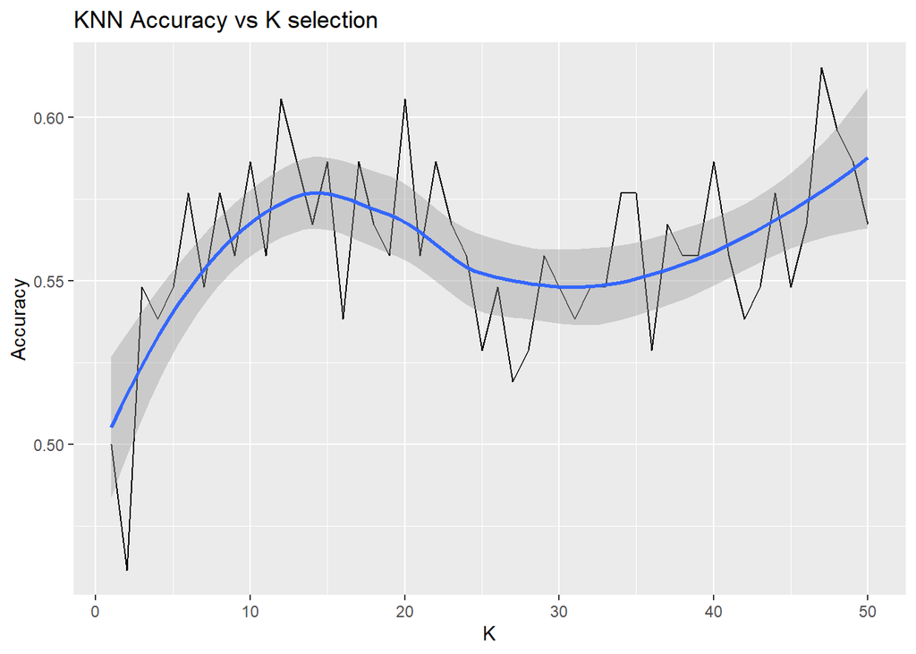

```r
ggplot(data.frame(K = 1:50, Accuracy = accuracy), aes(x = K, y = Accuracy)) +
  geom_line() +
  geom_smooth()+
  labs(title = "KNN Accuracy vs K selection")
```

```r
knn.pred = knn(train.X, test.X, train.Direction, k = which.max(accuracy))

confusionMatrix(data = knn.pred,
                reference = test$Direction,
                positive = "Up")
```

```
Confusion Matrix and Statistics

          Reference
Prediction Down Up
      Down   23 20
      Up     20 41

               Accuracy : 0.6154
                 95% CI : (0.5149, 0.7091)
    No Information Rate : 0.5865
    P-Value [Acc > NIR] : 0.311

                  Kappa : 0.207

 Mcnemar's Test P-Value : 1.000

            Sensitivity : 0.6721
            Specificity : 0.5349
         Pos Pred Value : 0.6721
         Neg Pred Value : 0.5349
             Prevalence : 0.5865
         Detection Rate : 0.3942
   Detection Prevalence : 0.5865
      Balanced Accuracy : 0.6035

       'Positive' Class : Up
```

The performance has definitely improved with K = 47 compared to K=1. However the P-value [Acc > NIR] = 0.311, which is more than 0.05 assuming we chose alpha to be 0.05, means that the model is not significantly better than the baseline classifier.

```r
# Logistic regression
train = Weekly[Weekly$Year <= 2008,]
test = Weekly[Weekly$Year > 2008,]

# Basic model
lm.fit = glm(Direction ~ ., data = train, family = binomial, control = list(maxit = 50))
predicted <- factor(ifelse(predict(lm.fit, newdata = test, type = "response") < 0.5, "Down", "Up"))
confusionMatrix(predicted, test$Direction, positive = "Up")
```

```
Confusion Matrix and Statistics

          Reference
Prediction Down Up
      Down   43  0
      Up      0 61

               Accuracy : 1
                 95% CI : (0.9652, 1)
    No Information Rate : 0.5865
    P-Value [Acc > NIR] : < 2.2e-16

                  Kappa : 1

 Mcnemar's Test P-Value : NA

            Sensitivity : 1.0000
            Specificity : 1.0000
         Pos Pred Value : 1.0000
         Neg Pred Value : 1.0000
             Prevalence : 0.5865
         Detection Rate : 0.5865
   Detection Prevalence : 0.5865
      Balanced Accuracy : 1.0000

       'Positive' Class : Up
```

```r
# Interaction with lag1 and lag2
interact.fit = glm(Direction ~ .+ Lag1 : Lag2, data = train, family = binomial, control = list(maxit = 50))
predicted <- factor(ifelse(predict(interact.fit, newdata = test, type = "response") < 0.5, "Down", "Up"))
confusionMatrix(predicted, test$Direction, positive = "Up")
```

```
Confusion Matrix and Statistics

          Reference
Prediction Down Up
      Down   43  1
      Up      0 60

               Accuracy : 0.9904
                 95% CI : (0.9476, 0.9998)
    No Information Rate : 0.5865
    P-Value [Acc > NIR] : <2e-16

                  Kappa : 0.9802

 Mcnemar's Test P-Value : 1

            Sensitivity : 0.9836
            Specificity : 1.0000
         Pos Pred Value : 1.0000
         Neg Pred Value : 0.9773
             Prevalence : 0.5865
         Detection Rate : 0.5769
   Detection Prevalence : 0.5769
      Balanced Accuracy : 0.9918

       'Positive' Class : Up
```

```r
# transformation of Lag1
transform.fit = glm(Direction ~ . + I(Lag1^2), data = train, family = binomial, control = list(maxit = 50))
predicted <- factor(ifelse(predict(transform.fit, newdata = test, type = "response") < 0.5, "Down", "Up"))
confusionMatrix(predicted, test$Direction, positive = "Up")
```

```
Confusion Matrix and Statistics

          Reference
Prediction Down Up
      Down   43  0
      Up      0 61

               Accuracy : 1
                 95% CI : (0.9652, 1)
    No Information Rate : 0.5865
    P-Value [Acc > NIR] : < 2.2e-16

                  Kappa : 1

 Mcnemar's Test P-Value : NA

            Sensitivity : 1.0000
            Specificity : 1.0000
         Pos Pred Value : 1.0000
         Neg Pred Value : 1.0000
             Prevalence : 0.5865
         Detection Rate : 0.5865
   Detection Prevalence : 0.5865
      Balanced Accuracy : 1.0000

       'Positive' Class : Up
```

All of these showed a close to 1 accuracy, this could be due to the small sample size or overfitting in the training data.

```r
# number of test sample
table(Weekly$Year)
```

```
1990 1991 1992 1993 1994 1995 1996 1997 1998 1999 2000 2001 2002 2003 2004 2005
  47   52   52   52   52   52   53   52   52   52   52   52   52   52   52   52
2006 2007 2008 2009 2010
  52   53   52   52   52
```

```r
nrow(test)
```

```
[1] 104
```

The test sample only contains weeks from 2009 and 2010 which adds up to 104 in total, let us redistribute the train-test separation and try again.

```r
# Logistic regression
train = Weekly[Weekly$Year <= 2000,]
test = Weekly[Weekly$Year > 2000,]

# Basic model
print("CM for basic model with everything")
```

```
[1] "CM for basic model with everything"
```

```r
lm.fit = glm(Direction ~ ., data = train, family = binomial, control = list(maxit = 50))
predicted <- factor(ifelse(predict(lm.fit, newdata = test, type = "response") < 0.5, "Down", "Up"))
confusionMatrix(predicted, test$Direction, positive = "Up")
```

```
Confusion Matrix and Statistics

          Reference
Prediction Down  Up
      Down  142   0
      Up     98 281

               Accuracy : 0.8119
                 95% CI : (0.7756, 0.8446)
    No Information Rate : 0.5393
    P-Value [Acc > NIR] : < 2.2e-16

                  Kappa : 0.6098

 Mcnemar's Test P-Value : < 2.2e-16

            Sensitivity : 1.0000
            Specificity : 0.5917
         Pos Pred Value : 0.7414
         Neg Pred Value : 1.0000
             Prevalence : 0.5393
         Detection Rate : 0.5393
   Detection Prevalence : 0.7274
      Balanced Accuracy : 0.7958

       'Positive' Class : Up
```

```r
# Interaction with lag1 and lag2
print("CM for interaction with lag1 and lag2")
```

```
[1] "CM for interaction with lag1 and lag2"
```

```r
interact.fit = glm(Direction ~ .+ Lag1 : Lag2, data = train, family = binomial, control = list(maxit = 50))
predicted <- factor(ifelse(predict(interact.fit, newdata = test, type = "response") < 0.5, "Down", "Up"))
confusionMatrix(predicted, test$Direction, positive = "Up")
```

```
Confusion Matrix and Statistics

          Reference
Prediction Down  Up
      Down  227   0
      Up     13 281

               Accuracy : 0.975
                 95% CI : (0.9577, 0.9866)
    No Information Rate : 0.5393
    P-Value [Acc > NIR] : < 2.2e-16

                  Kappa : 0.9496

 Mcnemar's Test P-Value : 0.0008741

            Sensitivity : 1.0000
            Specificity : 0.9458
         Pos Pred Value : 0.9558
         Neg Pred Value : 1.0000
             Prevalence : 0.5393
         Detection Rate : 0.5393
   Detection Prevalence : 0.5643
      Balanced Accuracy : 0.9729

       'Positive' Class : Up
```

```r
# transformation of Lag1
print("CM with transformation of Lag1 (lag1^2)")
```

```
[1] "CM with transformation of Lag1 (lag1^2)"
```

```r
transform.fit = glm(Direction ~ . + I(Lag1^2), data = train, family = binomial, control = list(maxit = 50))
predicted <- factor(ifelse(predict(transform.fit, newdata = test, type = "response") < 0.5, "Down", "Up"))
confusionMatrix(predicted, test$Direction, positive = "Up")
```

```
Confusion Matrix and Statistics

          Reference
Prediction Down  Up
      Down  199   0
      Up     41 281

               Accuracy : 0.9213
                 95% CI : (0.8948, 0.9429)
    No Information Rate : 0.5393
    P-Value [Acc > NIR] : < 2.2e-16

                  Kappa : 0.8396

 Mcnemar's Test P-Value : 4.185e-10

            Sensitivity : 1.0000
            Specificity : 0.8292
         Pos Pred Value : 0.8727
         Neg Pred Value : 1.0000
             Prevalence : 0.5393
         Detection Rate : 0.5393
   Detection Prevalence : 0.6180
      Balanced Accuracy : 0.9146

       'Positive' Class : Up
```

The result accuracies are still close to 1, which could be due to the small sample size or overfitting in the training data. This is hard to avoid with a small sample size. However out of these models the model with the interaction of lag1 and lag2 seems to be the best with the highest accuracy of 0.975. With P-Value [Acc > NIR] < 2.2e-16, we can conclude that the model is significantly better than the baseline classifier.

## 5 Bonus question: ISL Exercise 4.8.4 (30pts)

When the number of features p is large, there tends to be a deterioration in the performance of KNN and other local approaches that perform prediction using only observations that are near the test observation for which a prediction must be made. This phenomenon is known as the curse of dimensionality, and it ties into the fact that non-parametric approaches often perform poorly when p is large. We will now investigate this curse.

1. Suppose that we have a set of observations, each with measurements on p = 1 feature, X. We assume that X is uniformly (evenly) distributed on [0, 1]. Associated with each observation is a response value. Suppose that we wish to predict a test observation’s response using only observations that are within 10 % of the range of X closest to that test observation. For instance, in order to predict the response for a test observation with X = 0.6, we will use observations in the range [0.55, 0.65]. On average, what fraction of the available observations will we use to make the prediction?

**Answer:**

So on average, we can claim that the fraction of observations used to make each prediction will be slightly lower or about 10%.

2. Now suppose that we have a set of observations, each with measurements on p = 2 features, X1 and X2. We assume that (X1,X2) are uniformly distributed on [0, 1] × [0, 1]. We wish to predict a test observation’s response using only observations that are within 10 % of the range of X1 and within 10 % of the range of X2 closest to that test observation. For instance, in order to predict the response for a test observation with X1 = 0.6 and X2 = 0.35, we will use observations in the range [0.55, 0.65] for X1 and in the range [0.3, 0.4] for X2. On average, what fraction of the available observations will we use to make the prediction?

**Answer:**

Since we want the fraction of test observations that satisfy both predictors ranges, assuming that the two predictors are independent, the fraction of observations used to make each prediction will be 10% * 10% = 1%.

On average, we could say that the fraction of observations used to make each prediction will be lower or about 1%.

3. Now suppose that we have a set of observations on p = 100 features. Again the observations are uniformly distributed on each feature, and again each feature ranges in value from 0 to 1. We wish to predict a test observation’s response using observations within the 10 % of each feature’s range that is closest to that test observation. What fraction of the available observations will we use to make the prediction?

**Answer:**

Assuming that the predictors are independent, the fraction of observations used to make each prediction will be (0.1^{100}) which is a very small number. This is because the fraction of observations used to make each prediction will be 10% * 10% * 10% * … * 10% = (0.1^{100}). This is a very small number because the fraction of observations used to make each prediction will be 10% for each of the 100 features. This will bring down the average fraction of observations used to make the prediction to a very small number.

4. Using your answers to parts (a)–(c), argue that a drawback of KNN when p is large is that there are very few training observations “near” any given test observation.

**Answer:**

The fraction of observations that could count as a neighbour will be very small when p is large. This is because the fraction of observations used to make each prediction will be in this case, 10% for each of the features. As the the number of predictor increases, the smaller the fraction of test observations will be available to make prediction. This means that there are very few training observations “near” any given test observation. Making it harder to make accurate predictions.

5. Now suppose that we wish to make a prediction for a test observation by creating a p-dimensional hypercube centered around the test observation that contains, on average, 10 % of the training observations. For p = 1, 2, and 100, what is the length of each side of the hypercube? Comment on your answer. Note: A hypercube is a generalization of a cube to an arbitrary number of dimensions. When p = 1, a hypercube is simply a line segment, when p = 2 it is a square, and when p = 100 it is a 100-dimensional cube.

**Answer:**

$$\begin{align*}
0.1 = length^p\\
length = 0.1^\frac{1}{p}\\
\end{align*}$$

However we can see that as the number of predictors increases, the length of the sides of the hypercube will increase. This means that the hypercube will cover a larger area of the feature space. This will make it harder to make accurate predictions because the hypercube will cover a larger area of the feature space, and as a result, the fraction of training observations that will be used to make the prediction will be lower than 10%. As we can see for (p = 100), the length of the sides of the hypercube is 0.977, which is very close to 1. This means that the hypercube will cover almost the entire feature space, and as a result, the fraction of training observations that will be used to make the prediction will be very low.